# **secr** simulations STR

Murray Efford

2024-06-15

# Stratification and parameter variation STR

The simulations described here are part of a series documenting the effect of breaching assumptions of spatially explicit capture–recapture models.

Covariation of density and effort or detection leads to bias if not adequately modelled.

## Settings

Two square grids of 64 binary proximity detectors at spacing $2\sigma$.

The same conditions were used for simulation and fitting.

Base scenario

[output not shown]

## Package version, date and platform

```r
source('../setup.R')
source('stratumTable.R')
runsim  <- FALSE
cache   <- TRUE
figures <- TRUE
nrepl   <- 100
metadata(runsim) # if FALSE picks up saved metadata.RDS
```

```
## R version 4.3.2 (2023-10-31)
## Platform   x86_64-pc-linux-gnu (64-bit)
## Running    CentOS Linux 7 (Core)
## secr       4.6.7 2024-05-18
## secrdesign 2.9.2 2024-05-18
## Threads    40
## nrepl      100
## Run        Sat Jun 15 09:37:02 2024
```

## Simulation code

### First construct grids

```r
# start with 8 x 8 grids
grid1 <- grid2 <- make.grid(8,8, spacing = 40, detector = 'proximity')
grid2[,1] <- grid2[,1] + 480  # displace to right

covariates(grid1)$grid <- rep(factor(1, levels = 1:2), nrow(grid1))
covariates(grid2)$grid <- rep(factor(2, levels = 1:2), nrow(grid2))

# grids1a is a smaller grid 6 x 6
grid1a <- subset(grid1, !apply(grid1, 1, function(x) any(x<20 | x>260)))

# combine
grids <- rbind(grid1, grid2)
gridsa <- rbind(grid1a, grid2)

# stratify mask horizontally and vertically
mask <- make.mask(grids, buffer = 100, spacing = 10)
covariates(mask)$grid <- factor(1 + (mask$x>380))
covariates(mask)$D <- c(5,20)[covariates(mask)$grid]
covariates(mask)$gridy <- factor(1 + (mask$y>140))
covariates(mask)$Dy <- c(5,20)[covariates(mask)$gridy]

# pops for illustration
popargs <- list(D = 'D', core = mask, model2D = 'IHP')
pop <- do.call(sim.popn, popargs)
popargsy <- list(D = 'Dy', core = mask, model2D = 'IHP')
popy <- do.call(sim.popn, popargsy)
```

### Plot - as in Efford in prep. Study design

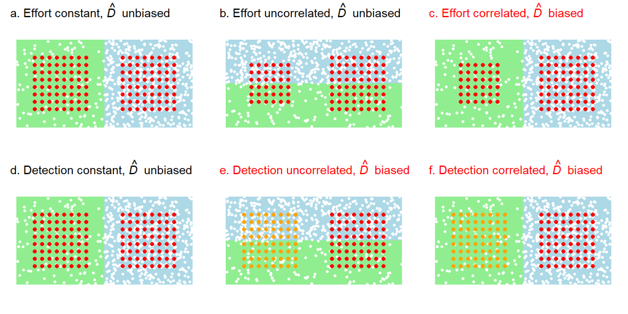

```r
par(mfrow=c(2,3), mar=c(1,1,2,1))

plot(mask, cov='grid', legend = FALSE, dots=F, col=c('lightgreen','lightblue'))
points(pop, pch=16, cex=0.7, col = 'white')
plot(grid1, add=T, detpar=list(pch=16, cex=0.7))
plot(grid2, add=T, detpar=list(pch=16, cex=0.7))
mtext (side=3, adj=0, expression(paste('a. Effort constant, ', hat(italic(D)), ~~'unbiased')), cex=0.9)

plot(mask, cov='gridy', legend = FALSE, dots=F, col=c('lightgreen','lightblue'))
points(popy, pch=16, cex=0.7, col = 'white')
plot(grid1a,add=T, detpar=list(pch=16, cex=0.7))
plot(grid2,add=T, detpar=list(pch=16, cex=0.7))
mtext (side=3, adj=0, expression(paste('b. Effort uncorrelated, ', hat(italic(D)), ~~'unbiased')), cex=0.9)

plot(mask, cov='grid', legend = FALSE, dots=F, col=c('lightgreen','lightblue'))
points(pop, pch=16, cex=0.7, col = 'white')
plot(grid1a,add=T, detpar=list(pch=16, cex=0.7))
plot(grid2,add=T, detpar=list(pch=16, cex=0.7))
mtext (side=3, adj=0, expression(paste('c. Effort correlated, ', hat(italic(D)), ~~'biased')), cex=0.9, col='red')

plot(mask, cov='grid', legend = FALSE, dots=F, col=c('lightgreen','lightblue'))
points(pop, pch=16, cex=0.7, col = 'white')
plot(grid1, add=T, detpar=list(pch=16, cex=0.7))
plot(grid2, add=T, detpar=list(pch=16, cex=0.7))
mtext (side=3, adj=0, expression(paste('d. Detection constant, ', hat(italic(D)), ~~'unbiased')), cex=0.9)

plot(mask, cov='gridy', legend = FALSE, dots=F, col=c('lightgreen','lightblue'))
points(popy, pch=16, cex=0.7, col = 'white')
plot(grid1,add=T, detpar=list(pch=16, fg='orange', cex=0.7))
plot(grid2,add=T, detpar=list(pch=16, cex=0.7))
mtext (side=3, adj=0, expression(paste('e. Detection uncorrelated, ', hat(italic(D)), ~~'biased')), cex=0.9, col='red')

plot(mask, cov='grid', legend = FALSE, dots=F, col=c('lightgreen','lightblue'))
points(pop, pch=16, cex=0.7, col = 'white')
plot(grid1,add=T, detpar=list(pch=16, fg='orange', cex=0.7))
plot(grid2,add=T, detpar=list(pch=16, cex=0.7))
mtext (side=3, adj=0, expression(paste('f. Detection correlated, ', hat(italic(D)), ~~'biased')), cex=0.9, col='red')
```

### Define STR scenarios

#### Varying effort

```r
# a. equal effort (2 64-detector grids)
# b. effort uncorrelated: patchy effort unrelated to density  (36-detector, 64-detector grids)
# c. naive: more effort where greater density  (36-detector, 64-detector grids)
# c1. modelling D  (36-detector, 64-detector grids)
# c2. independent estimates  (36-detector, 64-detector grids)

scen1 <- make.scenarios(trapsindex = c(1,2,2,2,2), D = 12.5, detectfn='HHN',
                       lambda0 = 0.1, sigma = 20, noccasions = 10)
scen1$popindex <- c(1,2,1,1,1)
scen1$fitindex <- c(1,1,1,2,3)
popnset <- list(popargs, popargsy)
trapset1 <- list(grids, gridsa)
fitarg1 <- list(list(detectfn = 'HHN', start = list(D = 12.5)),
               list(detectfn = 'HHN', start = list(D = 12.5), model = D~grid),
               list(detectfn = 'HHN', start = list(D = 12.5),
                    model = list(D~grid, lambda0~grid, sigma~grid)))
```

Also try varying allocation between low- and high-density strata. Number of detectors in each varies from 1 to 15 rows of 8 detectors, while keeping total constant at 128 detectors. Consider both high effort (‘v’, 10 occasions) and low effort (‘v4’, 4 occasions).

```r
# c1v. modelling D  (varying grids)
oney <- function (y = 8) {
    grid1 <- make.grid(8,y, detector = 'proximity', spacing = 40)
    grid2 <- make.grid(8,16-y, detector = 'proximity', spacing = 40)
    grid2[,1] <- grid2[,1] + 480  # displace to right
    rbind(grid1, grid2)
}
trapset1v <- lapply(15:1, oney)
maskv <- make.mask(trapset1v[[15]], buffer = 100, spacing = 10)
covariates(maskv)$grid <- factor(1 + (maskv$x>380))
covariates(maskv)$D <- c(5,20)[covariates(maskv)$grid]
scen1v <- make.scenarios(trapsindex = 1:15, D = 12.5, detectfn='HHN',
                       lambda0 = 0.1, sigma = 20, noccasions = 10, fitindex = 2)

scen1v4 <- make.scenarios(trapsindex = 1:15, D = 12.5, detectfn='HHN',
                       lambda0 = 0.1, sigma = 20, noccasions = 4, fitindex = 2)
popargsv <- list(D = 'D', core = maskv, model2D = 'IHP')
```

Alternatively, reduce number of occasions in the low-density stratum and correspondingly increase those in the high-density stratum:

```r
# c1vocc. modelling D  (varying usage on grids)
oneocc <- function (occ = 1, sumocc = 10) {
    grid1 <- make.grid(8,8, detector = 'proximity', spacing = 40)
    usage(grid1) <- matrix(0,nrow=64, ncol=sumocc-1)
    grid2 <- grid1
    usage(grid1)[,1:occ] <- 1
    usage(grid2)[,1:(sumocc-occ)] <- 1
    grid2[,1] <- grid2[,1] + 480  # displace to right
    rbind(grid1, grid2)
}
trapset1vocc <- lapply(1:9, oneocc)
# check reciprocal variation in effort
t(sapply(trapset1vocc, function(x) apply(usage(x),2,sum)))
# scenarios for total of 10 occasions
scen1vocc <- make.scenarios(trapsindex = 1:9, D = 12.5, detectfn='HHN',
                       lambda0 = 0.1, sigma = 20, noccasions = 9, fitindex = 2)
```

#### Varying detection

Use ‘groups’ to define sub-scenarios with differing detection on different subgrids.

```r
# d.  equal detection (repeats a. so not simulated)
# e.  detection uncorrelated: patchy detection unrelated to density
# e1. detection uncorrelated and modelled
# f.  detection correlated
# f1. detection correlated and modelled
# f2. detection correlated, D modelled
# f3. detection correlated and modelled with D

scen2 <- make.scenarios(fitindex=c(1,1,2,1,2,3,4), D = 12.5, groups = 1:2, detectfn='HHN',
                        lambda0 = 0.1, sigma = 20, noccasions = 10)
scen2$lambda0[3:14] <- rep(c(0.15, 0.05),6)
scen2$trapsindex <- scen2$group
popnset <- list(popargs, popargsy)
scen2$popindex <- rep(c(1,2,2,1,1,1,1), each = 2)
trapset2 <- list(grid1, grid2)
fitarg2 <- list(list(detectfn = 'HHN', start = list(D = 12.5)),
                list(detectfn = 'HHN', start = list(D = 12.5), model = lambda0~grid),
                list(detectfn = 'HHN', start = list(D = 12.5), model = D~grid),
                list(detectfn = 'HHN', start = list(D = 12.5), model = list(D~grid, lambda0~grid))                )
```

```r
scenarioSummary(scen1, trapset1)
```

```
##   scenario trapsindex noccasions nrepeats    D lambda0 sigma detectfn     En     Er      Em    En2
## 1        1          1         10        1 12.5     0.1    20       14 220.05 172.23 110.041 81.591
## 2        2          2         10        1 12.5     0.1    20       14 173.50 132.97  84.208 62.689
## 3        3          2         10        1 12.5     0.1    20       14 173.50 132.97  84.208 62.689
## 4        4          2         10        1 12.5     0.1    20       14 173.50 132.97  84.208 62.689
## 5        5          2         10        1 12.5     0.1    20       14 173.50 132.97  84.208 62.689
##      esa CF rotRSE rotRSEB arrayN arrayspace arrayspan saturation detperHR.median       k
## 1 17.604  1 0.0762  0.0608    128          2    40.497    0.26959               4 0.70711
## 2 13.880  1 0.0867  0.0704    100          2    37.947    0.26959               4 0.70711
## 3 13.880  1 0.0867  0.0704    100          2    37.947    0.26959               4 0.70711
## 4 13.880  1 0.0867  0.0704    100          2    37.947    0.26959               4 0.70711
## 5 13.880  1 0.0867  0.0704    100          2    37.947    0.26959               4 0.70711
```

### Run STR simulations

```r
sims1abc <- run.scenarios(
    nrepl     = nrepl,
    scenarios = scen1[1:3,],
    trapset   = trapset1,
    maskset   = mask,
    pop.args  = popnset,
    fit       = TRUE,
    fit.args  = fitarg1)
saveRDS(sims1abc, file = 'STRsims1abc.RDS')
```

Models with stratum-specific density estimates use `stratumTable` as the extractfn and cov = ‘grid’ as the stratification mask covariate (which happens in this case to be equal-area as in the default).

```r
sims1c1c2 <- run.scenarios(
    nrepl     = nrepl,
    scenarios = scen1[4:5,],
    trapset   = trapset1,
    maskset   = mask,
    pop.args  = popnset,
    fit       = TRUE,
    fit.args  = fitarg1,
    extractfn = stratumTable,
    cov       = 'grid')
saveRDS(sims1c1c2, file = 'STRsims1c1c2.RDS')
```

```r
sims1cv <- run.scenarios(
    nrepl     = nrepl,
    scenarios = scen1v,
    trapset   = trapset1v,
    maskset   = maskv,
    pop.args  = popargsv,
    fit       = TRUE,
    fit.args  = fitarg1,
    extractfn = stratumTable,
    cov       = 'grid')
saveRDS(sims1cv, file = 'STRsims1cv.RDS')
```

```r
sims1cv4 <- run.scenarios(
    nrepl     = nrepl,
    scenarios = scen1v4,
    trapset   = trapset1v,
    maskset   = maskv,
    pop.args  = popargsv,
    fit       = TRUE,
    fit.args  = fitarg1,
    extractfn = stratumTable,
    cov       = 'grid')
saveRDS(sims1cv4, file = 'STRsims1cv4.RDS')
```

```r
sims1cvocc <- run.scenarios(
    nrepl     = nrepl,
    scenarios = scen1vocc,
    trapset   = trapset1vocc,
    maskset   = maskv,
    pop.args  = popargsv,
    fit       = TRUE,
    fit.args  = fitarg1,
    extractfn = stratumTable,
    cov       = 'grid')
saveRDS(sims1cvocc, file = 'STRsims1cvocc.RDS')
```

Simulations with distinct lambda0 on each grid use append.capthist (new in secr 4.6.7) to combine the separately simulated capthist objects before a model is fitted.

```r
sims2e <- run.scenarios(
    nrepl     = nrepl,
    scenarios = scen2[3:4,],
    trapset   = list(grid1,grid2),
    maskset   = mask,
    pop.args  = popnset,
    fit.args  = fitarg2,
    fit       = TRUE,
    multisession = append.capthist)
saveRDS(sims2e, file = 'STRsims2e.RDS')
```

```r
sims2e1 <- run.scenarios(
    nrepl     = nrepl,
    scenarios = scen2[5:6,],
    trapset   = list(grid1,grid2),
    maskset   = mask,
    pop.args  = popnset,
    fit.args  = fitarg2,
    fit       = TRUE,
    multisession = append.capthist)
saveRDS(sims2e1, file = 'STRsims2e1.RDS')
```

```r
sims2f <- run.scenarios(
    nrepl     = nrepl,
    scenarios = scen2[7:8,],
    trapset   = list(grid1,grid2),
    maskset   = mask,
    pop.args  = popnset,
    fit.args  = fitarg2,
    fit       = TRUE,
    multisession = append.capthist)
saveRDS(sims2f, file = 'STRsims2f.RDS')
```

```r
sims2f1 <- run.scenarios(
    nrepl     = nrepl,
    scenarios = scen2[9:10,],
    trapset   = list(grid1,grid2),
    maskset   = mask,
    pop.args  = popnset,
    fit.args  = fitarg2,
    fit       = TRUE,
    multisession = append.capthist)
saveRDS(sims2f1, file = 'STRsims2f1.RDS')
```

```r
sims2f2 <- run.scenarios(
    nrepl     = nrepl,
    scenarios = scen2[11:12,],
    trapset   = list(grid1,grid2),
    maskset   = mask,
    pop.args  = popnset,
    fit.args  = fitarg2,
    fit       = TRUE,
    extractfn = stratumTable,
    cov       = 'grid',
    multisession = append.capthist)
saveRDS(sims2f2, file = 'STRsims2f2.RDS')
```

```r
sims2f3 <- run.scenarios(
    nrepl     = nrepl,
    scenarios = scen2[13:14,],
    trapset   = list(grid1,grid2),
    maskset   = mask,
    pop.args  = popnset,
    fit.args  = fitarg2,
    fit       = TRUE,
    extractfn = stratumTable,
    cov       = 'grid',
    multisession = append.capthist)
saveRDS(sims2f3, file = 'STRsims2f3.RDS')
```

## Results

Effort scenarios involve either two equal 64-detector grids or one 36-detector grid and one 64-detector grid.

Detection scenarios involve two equal 64-detector grids, with equal $\lambda_0$ (0.1) or unequal $\lambda_0$ (0.15,0.05).

Summary of simulations. Large relative bias in **bold** face. * area-weighted estimate of total density from stratified model

| Code | Series | Scenario | Description | Model | RB($\hat D$) |
| --- | --- | --- | --- | --- | --- |
| a | 1 | 1 | equal effort | D~1, lambda0~1, sigma~1 | +0.02 |
| b | 1 | 2 | effort uncorrelated | D~1, lambda0~1, sigma~1 | +0.02 |
| c | 1 | 3 | effort high where greater density | D~1, lambda0~1, sigma~1 | **+0.17** |
| c1 | 1 | 4 |  | D~grid, lambda0~1, sigma~1 | 0.00* |
| c2 | 1 | 5 |  | D~grid, lambda0~grid, sigma~grid | +0.02* |
| d | 2 | 1 | equal detection (repeats a) | D~1, lambda0~1, sigma~1 |  |
| e | 2 | 2 | detection uncorrelated | D~1, lambda0~1, sigma~1 | **–0.14** |
| e1 | 2 | 3 |  | D~1, lambda0~grid, sigma~1 | 0.00 |
| f | 2 | 4 | detection high where low density | D~1, lambda0~1, sigma~1 | **–0.15** |
| f1 | 2 | 5 |  | D~1, lambda0~grid, sigma~1 | **–0.18** |
| f2 | 2 | 6 |  | D~grid, lambda0~1, sigma~1 | **–0.15** * |
| f3 | 2 | 7 |  | D~grid, lambda0~grid, sigma~1 | +0.01 * |

### Varying effort (grid size)

`stratumSummary` is in ‘stratumTable.R’.

```r
source('stratumTable.R')
scen1[, -c(5,10)]
```

```
##   scenario trapsindex noccasions nrepeats lambda0 sigma detectfn recapfactor detindex fitindex
## 1        1          1         10        1     0.1    20       14           1        1        1
## 2        2          2         10        1     0.1    20       14           1        1        1
## 3        3          2         10        1     0.1    20       14           1        1        1
## 4        4          2         10        1     0.1    20       14           1        1        2
## 5        5          2         10        1     0.1    20       14           1        1        3
```

```r
estimateSummary(STRsims1abc)
```

```
##   scenario true.D nvalid    EST    seEST       RB      seRB      RSE    RMSE    rRMSE  COV
## 1        1   12.5    100 12.724 0.097622 0.017927 0.0078098 0.076383 0.99684 0.079747 0.96
## 2        2   12.5    100 12.692 0.116456 0.015359 0.0093165 0.086771 1.17452 0.093962 0.94
## 3        3   12.5    100 14.607 0.125002 0.168553 0.0100002 0.081004 2.44664 0.195731 0.47
```

```r
stratumSummary(STRsims1c1c2)
```

```
## $`4`
##          Ah  Wh       D     SED     lcl     ucl        RB      RSE  COV
## 1     23.04 0.5  5.0216 1.02189  3.3857  7.4561 0.0043184 0.203500 0.98
## 2     23.04 0.5 20.0408 1.69436 16.9859 23.6462 0.0020380 0.084545 0.96
## Total 46.08 1.0 12.5312 0.99025 10.5903 14.4720 0.0024941 0.079023 0.95
##
## $`5`
##          Ah  Wh      D    SED     lcl     ucl       RB      RSE  COV
## 1     23.04 0.5  5.119 1.2484  3.2074  8.2207 0.023803 0.243870 0.94
## 2     23.04 0.5 20.275 1.7438 17.1353 23.9905 0.013737 0.086008 0.96
## Total 46.08 1.0 12.697 1.0798 10.5806 14.8132 0.015750 0.085042 0.97
```

```r
stratumSummary(STRsims1cv)
```

```
## $`1`
##          Ah  Wh      D     SED     lcl     ucl        RB     RSE  COV
## 1     36.48 0.5  5.021 0.62253  3.9419  6.3969 0.0041932 0.12399 0.98
## 2     36.48 0.5 20.395 4.22179 13.6595 30.4842 0.0197467 0.20700 0.93
## Total 72.96 1.0 12.708 2.13406  8.5253 16.8906 0.0166360 0.16793 0.93
##
## $`2`
##          Ah  Wh       D     SED     lcl     ucl       RB     RSE  COV
## 1     36.48 0.5  5.0829 0.63643  3.9811  6.4912 0.016571 0.12521 0.88
## 2     36.48 0.5 20.4943 3.19710 15.1269 27.7784 0.024714 0.15600 0.90
## Total 72.96 1.0 12.7886 1.63039  9.5931 15.9841 0.023085 0.12749 0.90
##
## $`3`
##          Ah  Wh       D     SED     lcl     ucl         RB     RSE  COV
## 1     36.48 0.5  5.1257 0.65267  3.9981  6.5727  0.0251406 0.12733 0.95
## 2     36.48 0.5 19.7301 2.61749 15.2319 25.5627 -0.0134937 0.13266 0.96
## Total 72.96 1.0 12.4279 1.34913  9.7837 15.0722 -0.0057668 0.10856 0.94
##
## $`4`
##          Ah  Wh       D     SED     lcl     ucl         RB      RSE  COV
## 1     36.48 0.5  4.9604 0.65746  3.8304  6.4252 -0.0079204 0.132541 0.96
## 2     36.48 0.5 20.0874 2.32229 16.0280 25.1788  0.0043686 0.115609 0.95
## Total 72.96 1.0 12.5239 1.20714 10.1579 14.8898  0.0019108 0.096387 0.94
##
## $`5`
##          Ah  Wh       D     SED     lcl     ucl        RB      RSE  COV
## 1     36.48 0.5  5.0472 0.68492  3.8736  6.5777 0.0094374 0.135703 0.98
## 2     36.48 0.5 20.0339 2.09183 16.3361 24.5708 0.0016946 0.104415 0.93
## Total 72.96 1.0 12.5405 1.10091 10.3828 14.6983 0.0032432 0.087788 0.95
##
## $`6`
##          Ah  Wh       D     SED     lcl     ucl         RB      RSE  COV
## 1     36.48 0.5  5.0825 0.71501  3.8635  6.6879  0.0164973 0.140682 0.97
## 2     36.48 0.5 19.9502 1.91944 16.5294 24.0806 -0.0024900 0.096211 0.95
## Total 72.96 1.0 12.5163 1.02445 10.5085 14.5242  0.0013075 0.081849 0.91
##
## $`7`
##          Ah  Wh       D     SED     lcl     ucl          RB      RSE  COV
## 1     36.48 0.5  5.0538 0.74482  3.7924  6.7367  0.01075252 0.147379 0.96
## 2     36.48 0.5 19.9825 1.78758 16.7750 23.8041 -0.00087623 0.089458 0.93
```

[output cut: 34 more lines]

```
## 1     36.48 0.5  4.9993 1.21801  3.1277  8.0133 -0.00013308 0.243635 0.96
## 2     36.48 0.5 19.9891 1.33471 17.5398 22.7809 -0.00054260 0.066772 0.94
## Total 72.96 1.0 12.4942 0.90508 10.7203 14.2682 -0.00046069 0.072439 0.95
##
## $`14`
##          Ah  Wh       D     SED     lcl    ucl         RB      RSE  COV
## 1     36.48 0.5  4.9447 1.44249  2.8355  8.681 -0.0110688 0.291727 0.96
## 2     36.48 0.5 19.9652 1.27799 17.6135 22.631 -0.0017395 0.064011 0.94
## Total 72.96 1.0 12.4549 0.96625 10.5611 14.349 -0.0036053 0.077580 0.93
##
## $`15`
##          Ah  Wh       D    SED     lcl    ucl         RB      RSE  COV
## 1     36.48 0.5  4.8535 1.9219  2.3291 10.347 -0.0292921 0.395979 0.97
## 2     36.48 0.5 19.8275 1.2362 17.5490 22.402 -0.0086271 0.062346 0.96
## Total 72.96 1.0 12.3405 1.1470 10.0923 14.589 -0.0127601 0.092949 0.95
```

```r
stratumSummary(STRsims1cv4)
```

```
## $`1`
##          Ah  Wh       D    SED     lcl     ucl        RB     RSE  COV
## 1     36.48 0.5  5.3349 1.3622  3.2739  8.7574 0.0669750 0.25534 0.95
## 2     36.48 0.5 20.1685 7.4788 10.0408 40.9045 0.0084226 0.37082 0.96
## Total 72.96 1.0 12.7517 3.8046  5.2947 20.2086 0.0201331 0.29836 0.89
##
## $`2`
##          Ah  Wh       D    SED     lcl     ucl       RB     RSE  COV
## 1     36.48 0.5  5.2419 1.2730  3.2869  8.3943 0.048382 0.24284 0.98
## 2     36.48 0.5 21.3951 6.0108 12.5004 36.7908 0.069757 0.28094 0.97
## Total 72.96 1.0 13.3185 3.0739  7.2937 19.3434 0.065482 0.23080 0.94
##
## $`3`
##          Ah  Wh       D    SED     lcl    ucl       RB     RSE  COV
## 1     36.48 0.5  5.2123 1.2153  3.3254  8.191 0.042465 0.23316 0.97
## 2     36.48 0.5 21.5034 5.1517 13.5531 34.201 0.075169 0.23958 0.97
## Total 72.96 1.0 13.3579 2.6485  8.1669 18.549 0.068628 0.19827 0.95
##
## $`4`
##          Ah  Wh       D    SED     lcl     ucl         RB     RSE  COV
## 1     36.48 0.5  4.9772 1.1573  3.1779  7.8099 -0.0045617 0.23252 0.94
## 2     36.48 0.5 20.3715 4.4205 13.3954 31.0444  0.0185773 0.21699 0.97
## Total 72.96 1.0 12.6744 2.2871  8.1917 17.1571  0.0139495 0.18045 0.96
##
## $`5`
##          Ah  Wh       D    SED     lcl     ucl       RB     RSE  COV
## 1     36.48 0.5  5.2246 1.2199  3.3301  8.2137 0.044924 0.23349 0.95
## 2     36.48 0.5 20.9065 4.2479 14.1115 31.0354 0.045326 0.20319 0.94
## Total 72.96 1.0 13.0656 2.2116  8.7309 17.4002 0.045246 0.16927 0.92
##
## $`6`
##          Ah  Wh       D    SED     lcl     ucl       RB     RSE  COV
## 1     36.48 0.5  5.2661 1.2205  3.3677  8.2526 0.053211 0.23177 0.98
## 2     36.48 0.5 20.7705 3.8777 14.4694 29.8836 0.038524 0.18669 0.98
## Total 72.96 1.0 13.0183 2.0350  9.0298 17.0068 0.041462 0.15632 0.95
##
## $`7`
##          Ah  Wh       D    SED     lcl     ucl       RB     RSE  COV
## 1     36.48 0.5  5.2494 1.2611  3.3033  8.3574 0.049870 0.24025 0.94
## 2     36.48 0.5 21.1829 3.7979 14.9592 30.0364 0.059144 0.17929 0.96
```

[output cut: 34 more lines]

```
## 1     36.48 0.5  4.9674 1.7680  2.5374  9.8049 -0.0065149 0.35591 0.97
## 2     36.48 0.5 20.1039 2.7395 15.4168 26.2350  0.0051961 0.13627 0.93
## Total 72.96 1.0 12.5357 1.6361  9.3289 15.7424  0.0028539 0.13052 0.88
##
## $`14`
##          Ah  Wh       D    SED     lcl    ucl         RB     RSE  COV
## 1     36.48 0.5  4.8295 2.0609  2.2028 10.875 -0.0340932 0.42673 0.99
## 2     36.48 0.5 20.1425 2.5905 15.6743 25.895  0.0071272 0.12861 0.96
## Total 72.96 1.0 12.4860 1.6644  9.2239 15.748 -0.0011168 0.13330 0.92
##
## $`15`
##          Ah  Wh       D    SED    lcl    ucl       RB     RSE  COV
## 1     36.48 0.5  5.3116    NaN    NaN    NaN 0.062328     NaN   NA
## 2     36.48 0.5 20.3403 2.5572 15.918 26.005 0.017017 0.12572 0.92
## Total 72.96 1.0 12.8260    NaN    NaN    NaN 0.026079     NaN   NA
```

```r
stratumSummary(STRsims1cvocc)
```

```
## $`1`
##          Ah  Wh       D    SED     lcl    ucl         RB      RSE  COV
## 1     36.48 0.5  5.0916 1.9204  2.5193 10.481  0.0183230 0.377171 0.95
## 2     36.48 0.5 19.8338 1.8020 16.6053 23.692 -0.0083099 0.090853 0.93
## Total 72.96 1.0 12.4627 1.3237  9.8683 15.057 -0.0029834 0.106212 0.91
##
## $`2`
##          Ah  Wh       D    SED     lcl     ucl       RB      RSE  COV
## 1     36.48 0.5  5.1515 1.4586  2.9962  8.8922 0.030299 0.283136 0.96
## 2     36.48 0.5 20.2251 1.9944 16.6796 24.5272 0.011257 0.098609 0.96
## Total 72.96 1.0 12.6883 1.2383 10.2612 15.1154 0.015066 0.097597 0.93
##
## $`3`
##          Ah  Wh       D    SED    lcl     ucl        RB      RSE  COV
## 1     36.48 0.5  5.1555 1.2474  3.235  8.2366 0.0310958 0.241957 0.95
## 2     36.48 0.5 20.0801 2.1560 16.281 24.7705 0.0040053 0.107371 0.93
## Total 72.96 1.0 12.6178 1.2479 10.172 15.0637 0.0094234 0.098903 0.88
##
## $`4`
##          Ah  Wh       D    SED     lcl     ucl        RB     RSE  COV
## 1     36.48 0.5  5.0132 1.1234  3.2510  7.7402 0.0026411 0.22409 0.94
## 2     36.48 0.5 20.0468 2.3845 15.8932 25.2922 0.0023418 0.11895 0.97
## Total 72.96 1.0 12.5300 1.3195  9.9439 15.1162 0.0024017 0.10531 0.93
##
## $`5`
##          Ah  Wh       D    SED     lcl     ucl       RB     RSE  COV
## 1     36.48 0.5  5.1313 1.0854  3.4077  7.7364 0.026262 0.21153 0.97
## 2     36.48 0.5 20.9054 2.8237 16.0658 27.2139 0.045270 0.13507 0.97
## Total 72.96 1.0 13.0184 1.5140 10.0510 15.9857 0.041468 0.11629 0.95
##
## $`6`
##          Ah  Wh       D    SED     lcl     ucl       RB     RSE  COV
## 1     36.48 0.5  5.0901 1.0424  3.4235  7.5765 0.018014 0.20479 0.96
## 2     36.48 0.5 20.4241 3.1963 15.0649 27.7159 0.021204 0.15650 0.94
## Total 72.96 1.0 12.7571 1.6824  9.4597 16.0545 0.020566 0.13188 0.96
##
## $`7`
##          Ah  Wh       D    SED     lcl     ucl        RB     RSE  COV
## 1     36.48 0.5  5.0551 1.0008  3.4450  7.4282 0.0110237 0.19797 0.94
## 2     36.48 0.5 20.1185 3.6329 14.1708 28.5940 0.0059266 0.18057 0.92
## Total 72.96 1.0 12.5868 1.8863  8.8897 16.2840 0.0069461 0.14986 0.85
##
## $`8`
##          Ah  Wh       D     SED     lcl     ucl         RB     RSE  COV
## 1     36.48 0.5  4.9864 0.96929  3.4228  7.2797 -0.0027182 0.19439 0.95
## 2     36.48 0.5 20.8310 4.38949 13.8641 31.3749  0.0415510 0.21072 0.94
## Total 72.96 1.0 12.9087 2.24938  8.5000 17.3174  0.0326972 0.17425 0.90
##
## $`9`
##          Ah  Wh      D     SED     lcl     ucl         RB     RSE  COV
## 1     36.48 0.5  4.995 0.91941  3.4952  7.1474 -0.0010047 0.18407 0.97
## 2     36.48 0.5 20.651 5.18422 12.7317 33.5453  0.0325264 0.25105 1.00
## Total 72.96 1.0 12.823 2.63374  7.6607 17.9848  0.0258201 0.20540 0.96
```

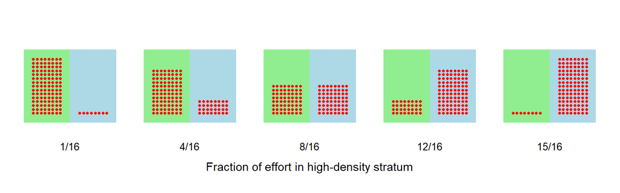

```r
plotone <- function(tr) {
    plot(maskv, cov='grid', legend = FALSE, dots=F, col=c('lightgreen','lightblue'))
    plot (tr, add = TRUE, detpar=list(pch=16, cex=0.5))
}
par(mfrow = c(1,5), mar = c(1,1,1,1), oma = c(3,1,1,1))
sapply(trapset1v[c(1,4,8,12,15)], plotone)
mtext(paste0(c(1,4,8,12,15), '/16'), outer=TRUE, side = 1, line = -2,
      at= c(0.1, 0.3, 0.5, 0.7, 0.9), cex = 0.8)
mtext('Fraction of effort in high-density stratum',
      outer = TRUE, side=1, line=0, cex=0.9)
```

Figure: Varying allocation of effort; examples from full spectrum.

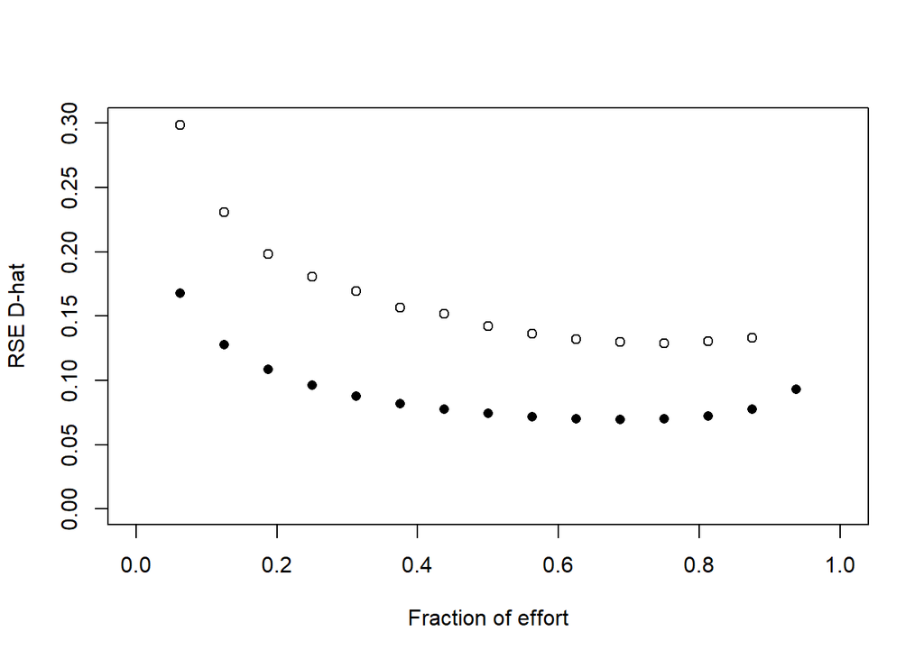

```r
source('stratumTable.R')
ss1cv <- stratumSummary(STRsims1cv)
ss1cv4 <- stratumSummary(STRsims1cv4)
par(mfrow = c(1,1))
plot(0,0, type = 'n', xlim = c(0,1), ylim = c(0.0,0.30),
     xlab = 'Fraction of effort',
     ylab = 'RSE D-hat')
x <- (1:15)/16
rse1cv <- sapply(ss1cv, '[', 'Total','RSE')
rse1cv4 <- sapply(ss1cv4, '[', 'Total','RSE')
points(x, rse1cv, pch = 16)
points(x, rse1cv4, pch = 1)
```

Figure: Effect of varying allocation of effort on precision of $\hat D$. Open circles 4 occasions, filled circles 10 occasions.

### Varying detection (parameter lambda0)

```r
scen2[, -c(5,10)]
```

```
##    scenario group trapsindex noccasions    D lambda0 sigma detectfn popindex detindex fitindex
## 1         1     1          1         10 12.5    0.10    20       14        1        1        1
## 2         1     2          2         10 12.5    0.10    20       14        1        1        1
## 3         2     1          1         10 12.5    0.15    20       14        2        1        1
## 4         2     2          2         10 12.5    0.05    20       14        2        1        1
## 5         3     1          1         10 12.5    0.15    20       14        2        1        2
## 6         3     2          2         10 12.5    0.05    20       14        2        1        2
## 7         4     1          1         10 12.5    0.15    20       14        1        1        1
## 8         4     2          2         10 12.5    0.05    20       14        1        1        1
## 9         5     1          1         10 12.5    0.15    20       14        1        1        2
## 10        5     2          2         10 12.5    0.05    20       14        1        1        2
## 11        6     1          1         10 12.5    0.15    20       14        1        1        3
## 12        6     2          2         10 12.5    0.05    20       14        1        1        3
## 13        7     1          1         10 12.5    0.15    20       14        1        1        4
## 14        7     2          2         10 12.5    0.05    20       14        1        1        4
```

```r
rbind(
    estimateSummary(STRsims2e,  true = 12.5),
    estimateSummary(STRsims2e1, true = 12.5),
    estimateSummary(STRsims2f,  true = 12.5),
    estimateSummary(STRsims2f1, true = 12.5)
)
```

```
##   scenario true.D nvalid    EST    seEST        RB      seRB      RSE    RMSE    rRMSE  COV
## 1        2   12.5    100 10.756 0.079470 -0.139530 0.0063576 0.077308 1.91499 0.153199 0.48
## 2        3   12.5    100 12.542 0.098141  0.003355 0.0078512 0.081872 0.97739 0.078191 0.98
## 3        4   12.5    100 10.607 0.092324 -0.151415 0.0073859 0.093554 2.10384 0.168307 0.54
## 4        5   12.5    100 10.197 0.094383 -0.184245 0.0075506 0.093717 2.48717 0.198973 0.43
```

```r
stratumSummary(STRsims2f2)
```

```
## $`6`
##          Ah  Wh       D     SED     lcl     ucl       RB      RSE  COV
## 1     23.04 0.5  6.6371 0.98218  4.9750  8.8581  0.32742 0.147983 0.55
## 2     23.04 0.5 14.5775 1.56331 11.8219 17.9775 -0.27112 0.107242 0.11
## Total 46.08 1.0 10.6073 0.92397  8.7964 12.4183 -0.15142 0.087107 0.49
```

```r
stratumSummary(STRsims2f3)
```

```
## $`7`
##          Ah  Wh       D     SED     lcl     ucl       RB     RSE  COV
## 1     23.04 0.5  5.1045 0.73967  3.8489  6.7722 0.020897 0.14491 0.97
## 2     23.04 0.5 20.2583 2.89562 15.3357 26.7780 0.012913 0.14294 0.96
## Total 46.08 1.0 12.6814 1.49616  9.7490 15.6138 0.014510 0.11798 0.97
```

Note: rRMSE is the root-mean-square error divided by the true density.

$\mbox{rRMSE}(\hat D) = \frac{1}{D} \sqrt {\frac{1}{N} \sum_{i=1}^N {(D - \hat D_i)^2}}$

$\mbox{RB}(\hat D) = \frac{1}{N} \sum_{i=1}^N {(\hat D_i - D)}/D$